# EDA of feature ideas

```r
suppressMessages(library(ggplot2))
#library(plotly)
suppressMessages(library(dplyr))
suppressMessages(library(tibble))
suppressMessages(library(readr)) # str_c, str_sub
suppressMessages(library(tidyr))
suppressMessages(library(stringr))
suppressMessages(library(lattice)) # splom
suppressMessages(library(MASS)) # for lm.ridge and boxcox, also fucks up dplyrs select
suppressMessages(library(lsmeans)) # for adjusted means
suppressMessages(library(caret)) # confusionMatrix
suppressMessages(library(ROCR))
library(RODBC)
drv <- odbcDriverConnect('driver={SQL Server};server=THE-ENTERPRISE\\SQLEXPRESS;database=WideWorldImporters;trusted_connection=true')

train <- tbl_df(sqlQuery(drv, 'select * from feature_table_train;'))
```

# Lets alter our appraoch: lets identify which customers we should pursue by classifying the very large orders

- we’ll derive features based on a given customers history
  - we could also derive features based on history of each item
- as opposed to before where we were classifying the orders bsaed on being greater than the mean, and
- we’ll need to filter to ensure we have enough data for each feature as well

#### lets decide on a cutoff point for our model

- note the number of bins makes a large difference on the interpretation, I’d always recommend varying number of bins in particular when dealing w bi or multimodal distributions (which you may not even know you have if you dont alter the bin sizes )
  - (see the diamonds example here: http://r4ds.had.co.nz/exploratory-data-analysis.html#variation)

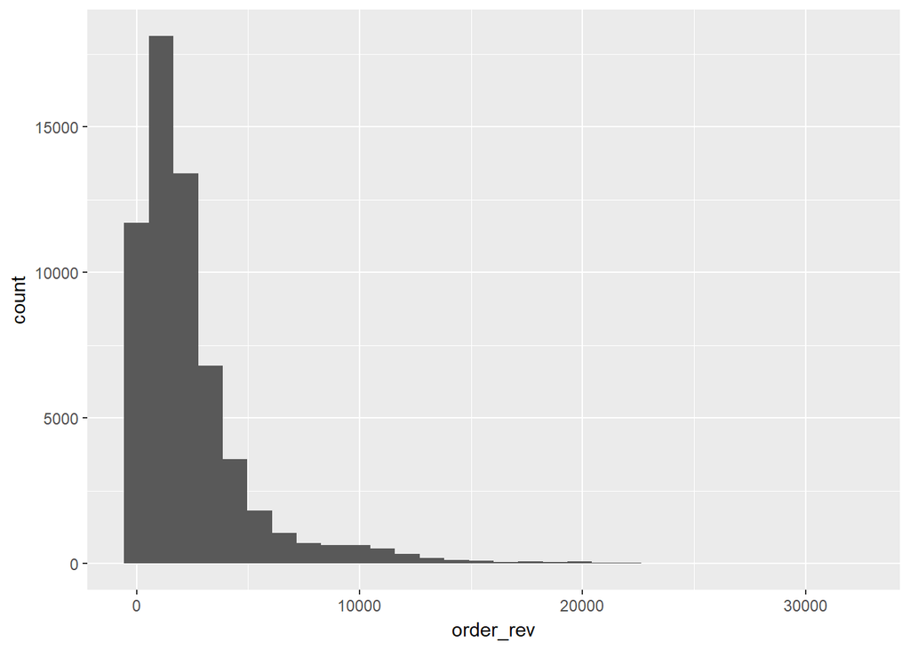

```r
ggplot(train, aes(order_rev)) +
  geom_histogram()
```

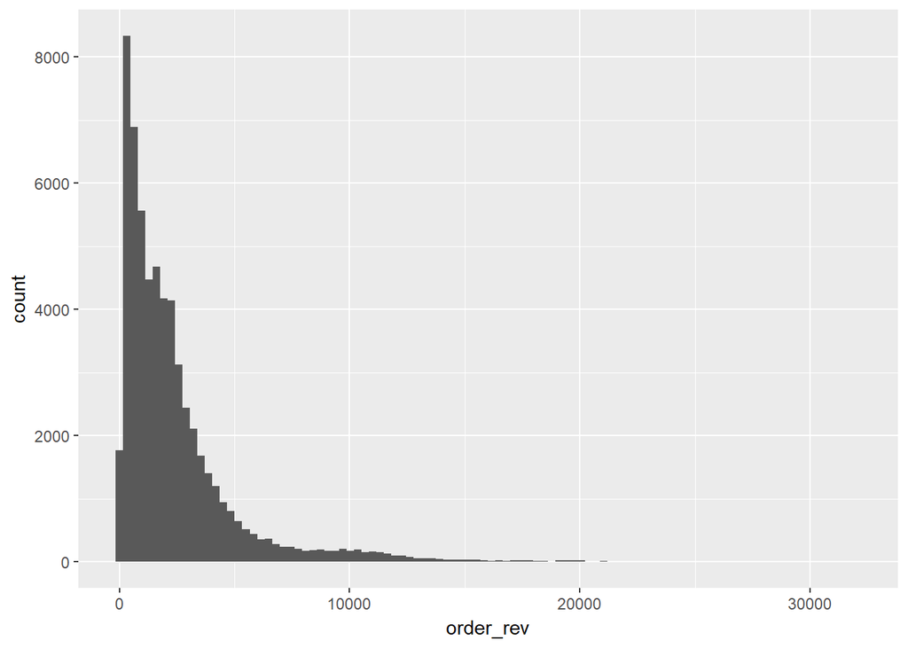

```r
ggplot(train, aes(order_rev)) +
  geom_histogram(bins=100)
```

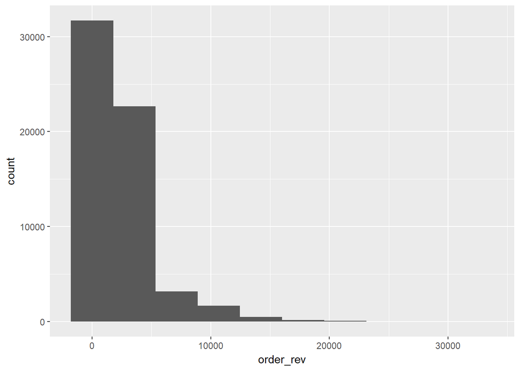

```r
ggplot(train, aes(order_rev)) +
  geom_histogram(bins=10)
```

### lets consider 10,000

- some questions?
  - what proportion of our entire data set does this consitute?
  - how concentrated is this with individual clients?
  - for clients in that are in the 1 comma club what proportion of all of their orders are in here?
- hopes and dreams (feature ideas):
  - ideally we want to see indivuals who have been in this club are likely to return => % of previous purchases > 10g will be a decent feature
  - another nice feature could be looking at clients spending over time
    - notice if theres some distinguishable (hopefully linear) trends then we can leverage this
  - hopefully there are certain products that are more likely to land us in the infamous 1 comma club
    - could give us some insight into which products we should be pitching to our clients
    - we can derive features for this similarly to above take a look at the previous times this was sold, proportions in the club, avg order, and vary the time interval were applying on (lifetime, 30 days, 3 months, …)
    - could be the case were no client is always in the club, but is when we sell them these specific products

```r
sum(train$order_rev > 10000) / nrow(train)
```

```
## [1] 0.0306
```

```r
comma_stats = train %>% group_by(CustomerID) %>% summarise(num_comma = sum(order_rev > 10000),
                                             prop_comma = num_comma / n(), n = n()) %>%
  arrange(-prop_comma)

comma_stats
```

```
## # A tibble: 663 x 4
##    CustomerID num_comma prop_comma     n
##         <int>     <int>      <dbl> <int>
##  1        996         9 0.10000000    90
##  2       1056         1 0.10000000    10
##  3        109         7 0.09333333    75
##  4        945         7 0.09333333    75
##  5       1058         1 0.09090909    11
##  6       1003         6 0.08450704    71
##  7        813         8 0.08333333    96
##  8        870         8 0.08333333    96
##  9        413         8 0.08080808    99
## 10        526         6 0.07594937    79
## # ... with 653 more rows
```

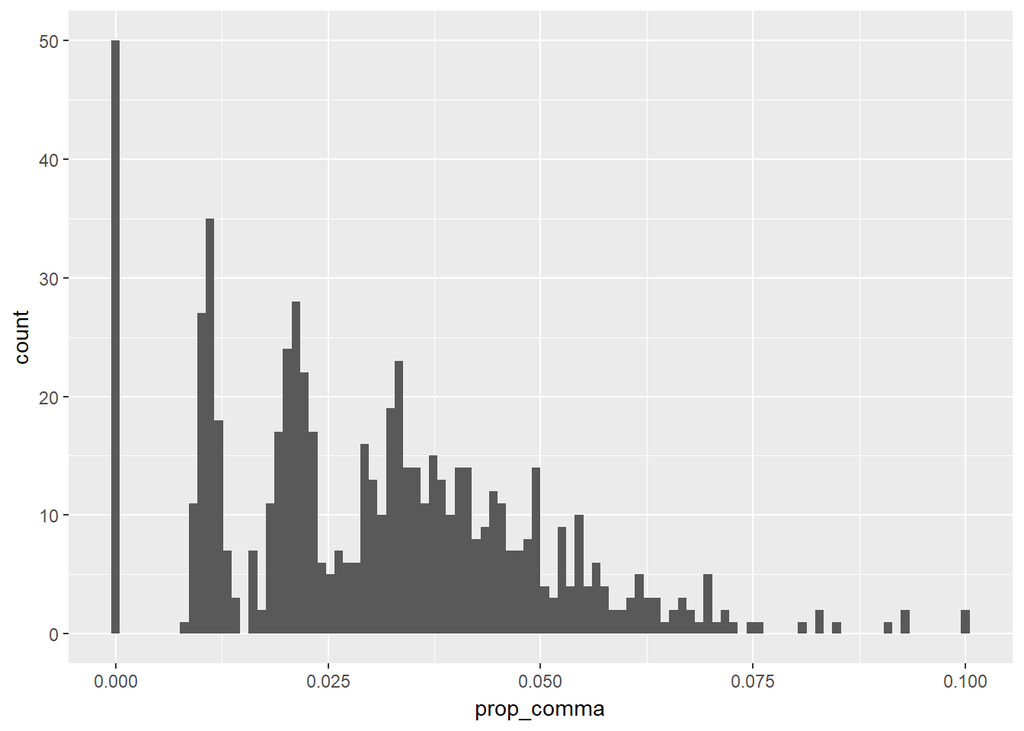

```r
ggplot(comma_stats, aes(prop_comma)) +
  geom_histogram(bins=100)
```

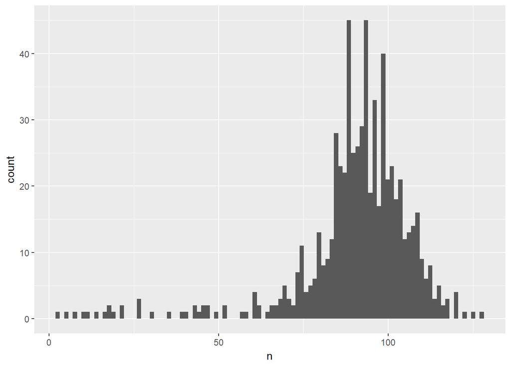

```r
ggplot(comma_stats, aes(n)) +
  geom_histogram(bins=100)
```

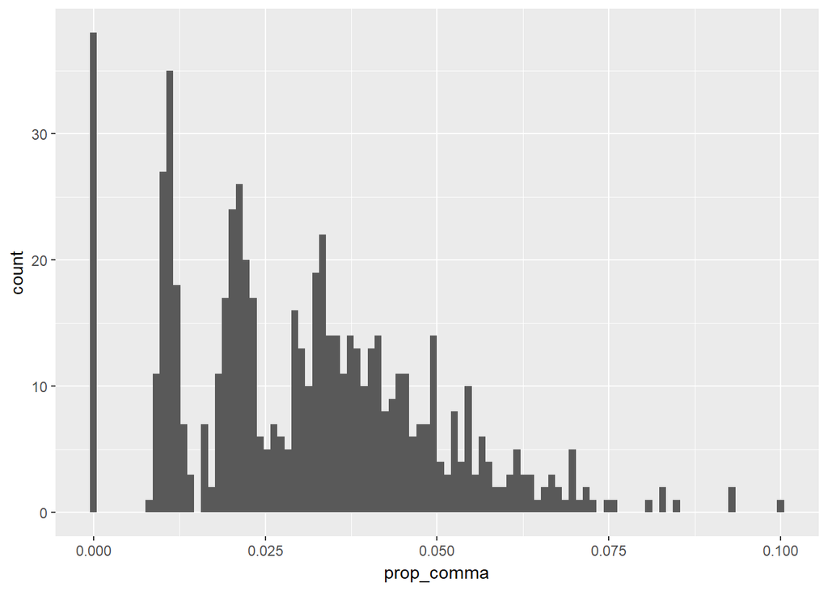

```r
ggplot(comma_stats %>% filter(n > 50),
       aes(prop_comma)) +
  geom_histogram(bins=100)
```

very interesting - looks like we have some clusters! - notice too few of bins may have missed this - it appears like we have some big spenders in various groups - likely our model will only consider indiduals who have been in here before, or potentially if theyre really trending towards it

- **notice the filtering step**
  - if we dont filter we’ll have those clients with < 10 purchases contaminating our perspective
  - in particularly import in feature engineering
  - here is why

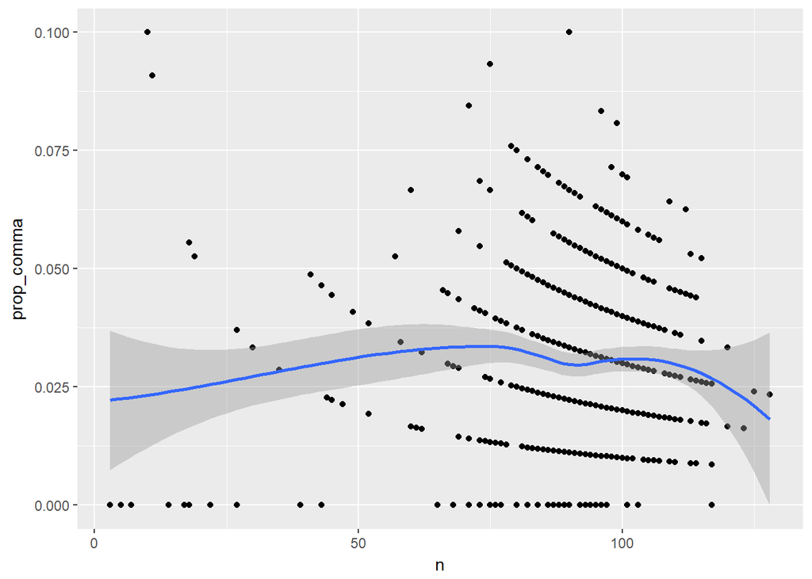

```r
ggplot(comma_stats, aes(n, prop_comma)) +
  geom_point() +
  geom_smooth()
```

- first off, weird pattern?
  - maybe because of the data generation?
  - either way its certainly something we can take to our advantage
- notice the variance in the estimates < 10, this always happens
  - checkout this book on baseball stats for how to handle this if you need to use the smaller sample sizes (emprical bayes): http://varianceexplained.org/r/empirical-bayes-book/
- these plots are another good way for you to decide on your cutoffs for features
- why dont we want the features < 10
  - its sort of like a 5 star movie review with 5 response, vs one with 100

#### lets change our approach now, we know we’ve got some big spenders, lets see how we can make them spend

- more questions:
  - is there something that all of these big spenders like?
  - or do each of them have their own cryponite (R doesnt have spellcheck :))
- we removed the product information because there were duplcates per order
  - lets bring it back and see if we should leverage it
  - this happens all the time btw, which is why modular and readable code is so handy

start with general high ticket items w out isolating to big spenders

```r
product_info <- tbl_df(sqlQuery(drv, 'select * from Sales.OrderLines;')) %>% mutate(product_rev = Quantity * UnitPrice)

traint <- train %>% inner_join(product_info, on='OrderID')
# notice we increase the number of rows bc of dup keys in product info
dim(traint)
```

```
## [1] 188716     35
```

```r
dim(train)
```

```
## [1] 60000    23
```

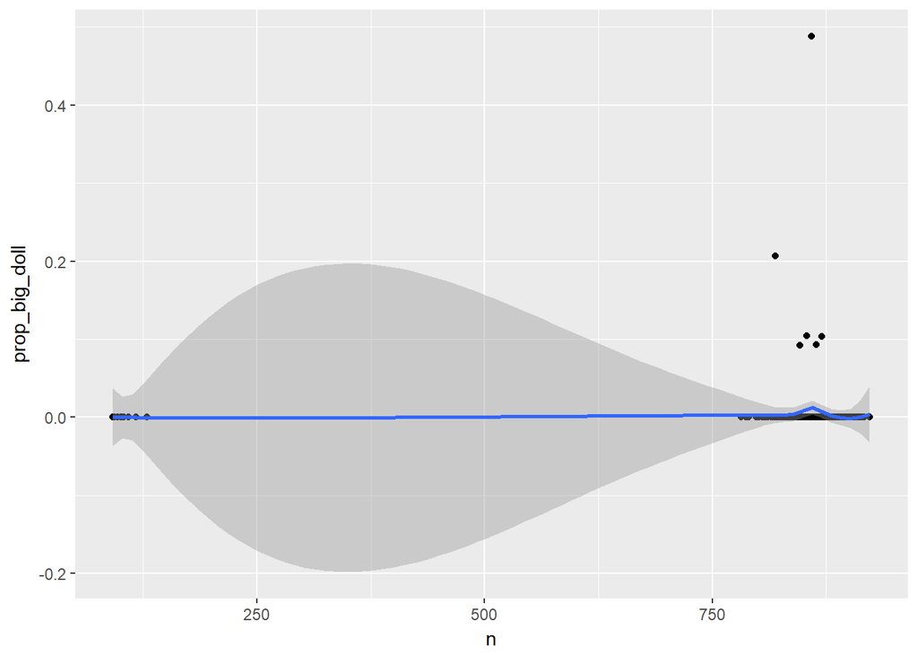

```r
prod_info2 <- traint %>% group_by(StockItemID) %>% summarise(count_big_doll = sum(product_rev > 10000), n=n(), prop_big_doll = count_big_doll / n)

ggplot(prod_info2, aes(n, prop_big_doll)) +
  geom_point() +
  geom_smooth()
```

##### notice we increase the number of rows bc of dup keys in product info

#### notice using order_revenue instead of product revenue below would bias results

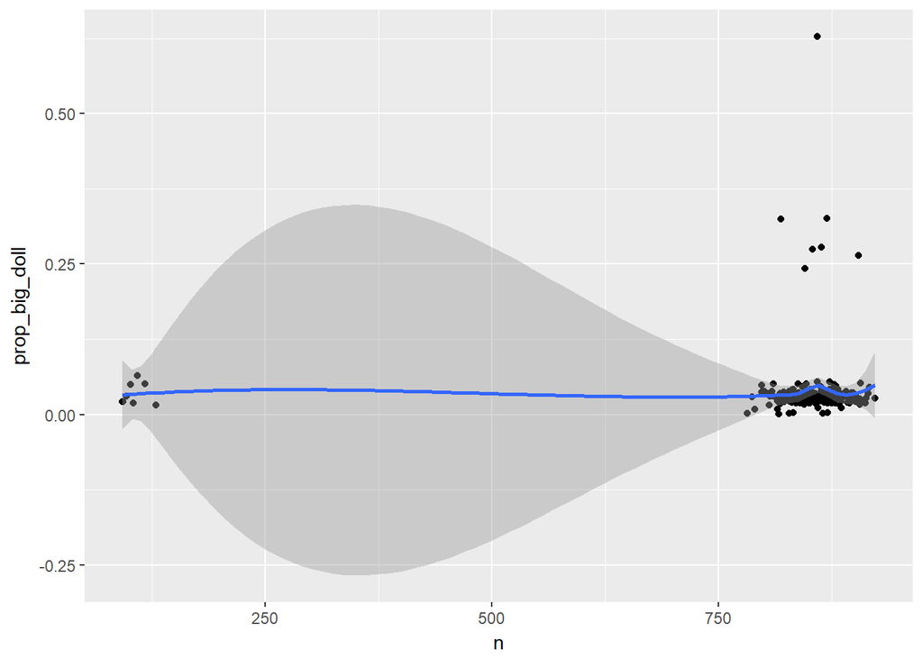

```r
prod_info3 <- traint %>% group_by(StockItemID) %>% summarise(count_big_doll = sum(order_rev > 10000), n=n(), prop_big_doll = count_big_doll / n)

ggplot(prod_info3, aes(n, prop_big_doll)) +
  geom_point() +
  geom_smooth()
```

### here we can see theres some pretty good candidate products for us with large counts too

- may want to consider a feature = n > 500, prop > .05, as an indicator

### lets try filtering to big spenders and our selected itmes

```r
cands <- traint %>%
  inner_join(prod_info2 %>% filter(n > 500, prop_big_doll > .05),
                      by='StockItemID') %>%
  inner_join(comma_stats %>% filter(n > 50, prop_comma > .05),
             by='CustomerID')

cands %>% summarise(sum(order_rev > 10000) / nrow(cands), nrow(cands))
```

```
## # A tibble: 1 x 2
##   `sum(order_rev > 10000)/nrow(cands)` `nrow(cands)`
##                                  <dbl>         <int>
## 1                             0.530474           886
```

```r
traint %>% summarise(sum(order_rev > 10000) / nrow(traint), nrow(traint))
```

```
## # A tibble: 1 x 2
##   `sum(order_rev > 10000)/nrow(traint)` `nrow(traint)`
##                                   <dbl>          <int>
## 1                            0.03838572         188716
```

- not bad

### lets isolate into big spenders and look at their behaviour overtime and within certain products

- todo